# Estableciendo relaciones

En la clase pasada aprendimos a relacionar variables ya sea:

- numérica vs numérica.
- discreta vs numérica.
- numérica vs discreta.

Pero llega un punto en donde necesitamos saber si nuestras variables están correlacionadas y hasta que punto, también si cambian conjuntamente

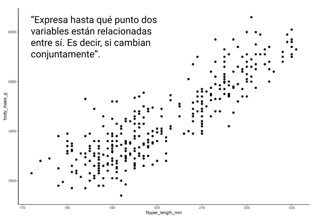

Ejemplo tenemos las variables:

- longitud de ala
- peso de pingüino

Y la gráfica anterior parece describir que:

- Un aumento en la longitud de ala parece implicar un aumento en el peso del pingüino. Podría tener sentido de que si tienes mas masa por longitud, implica que peses más.

Realmente podemos decir que están correlacionadas, pero ¿qué tanto?

### Coeficiente de correlación

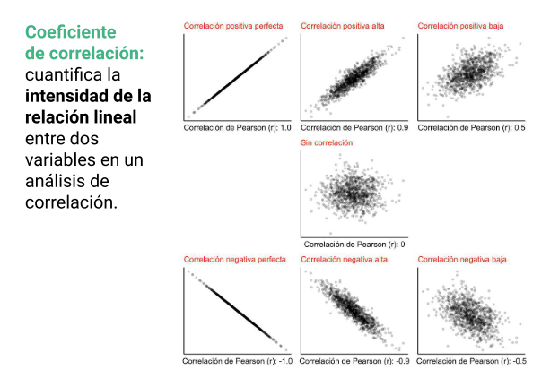

Usamos un coeficiente de relación para ser exacto, el **coeficiente de Pearson**.

Este cuantifica la intensidad de una relación lineal, es muy importante hacer hincapié en que es **lineal**.

#### ¿Cómo se interpreta el coeficiente?

Tenemos números que van de -1 a 1 y pasando por 0 (significa que no existe correlación). Para los demás casos:

- 1: Correlación positiva, significa que un cambio positivo en X, indica un cambio positivo en Y.
- -1: Correlación negativa, significa que un cambio positivo en X, indica un cambio negativo en Y.

Entonces los valores entre este rango indican un grado de correlación. Sin embargo este parámetro puede indicar si podemos continuar con el análisis de nuestra variable. Pero siempre tenemos que observar los datos para hacer un correcto análisis.

### IMPORTANTE

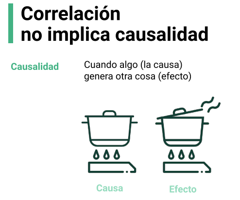

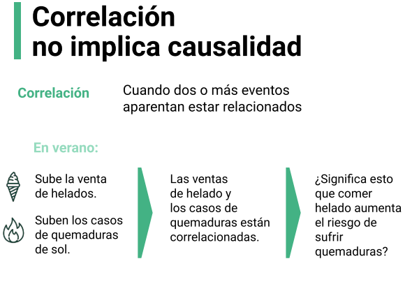

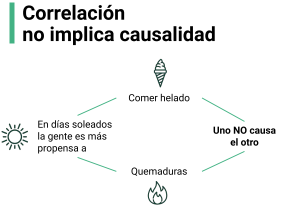

Lo que quiere decir es que aunque pueda existir una correlación, ambos eventos son excluyentes y uno no es la causa del otro.

Esto es muy importante, porque no siempre podemos saber si una variable está causando el efecto de otra variable. Para determinarlo se necesita más información y más pruebas o experimentos, para poder comprobar que existe una causa a cierto efecto.

```python
# Importando librerías
import empiricaldist
import janitor
import matplotlib.pyplot as plt
import numpy as np
import palmerpenguins
import pandas as pd
import scipy.stats
import seaborn as sns
import sklearn.metrics
import statsmodels.api as sm
import statsmodels.formula.api as smf
import statsmodels.stats as ss
import session_info
```

## Establecer apariencia general de las gráficas

```python
%matplotlib inline
sns.set_style(style='whitegrid')
sns.set_context(context='notebook')
plt.rcParams['figure.figsize'] = (11, 9.4)

penguin_color = {
    'Adelie': '#ff6602ff',
    'Gentoo': '#0f7175ff',
    'Chinstrap': '#c65dc9ff'
}
```

## Cargar los datos

### Datos Preprocesados

```python
preprocessed_penguins_df = pd.read_csv('dataset/penguins.csv')
```

## Matrices de correlación

### ¿Existe una correlación lineal entre alguna de nuestras variables?

Para responder analicemos nuestros datos.

```python
preprocessed_penguins_df.corr(numeric_only=True)
```

|  | bill_length_mm | bill_depth_mm | flipper_length_mm | body_mass_g | year |
| --- | --- | --- | --- | --- | --- |
| bill_length_mm | 1.000000 | -0.235053 | 0.656181 | 0.595110 | 0.054545 |
| bill_depth_mm | -0.235053 | 1.000000 | -0.583851 | -0.471916 | -0.060354 |
| flipper_length_mm | 0.656181 | -0.583851 | 1.000000 | 0.871202 | 0.169675 |
| body_mass_g | 0.595110 | -0.471916 | 0.871202 | 1.000000 | 0.042209 |
| year | 0.054545 | -0.060354 | 0.169675 | 0.042209 | 1.000000 |

Estos son los coeficientes de correlación de Pearson de todas nuestras variables, en la diagonal vamos a ver que hay un 1, debido a que cada variable comparada consigo misma es lo mismo; por lo tanto tiene una correlación de 1.

### ¿Cómo puedo visualizar los coeficientes de correlación?

Seaborn nos provee una función accesible, rápida y visual.

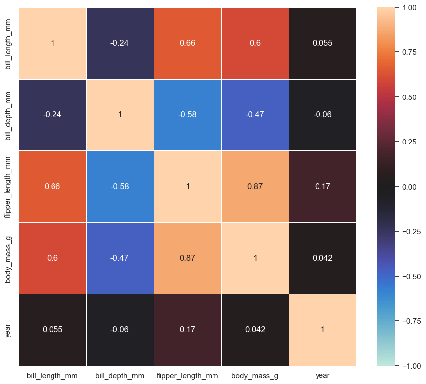

```python
sns.heatmap(
    data=preprocessed_penguins_df.corr(numeric_only=True),
    center=0,
    vmin=-1,
    vmax=1,
    linewidths=0.5,
    annot=True
)
```

Luce un poco raro por que la paleta de color puede no ser la adecuada.

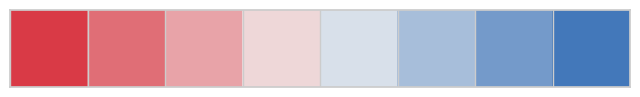

```python
# Create a diverging palette
palette = sns.diverging_palette(10,250, n=8)

# Display the palette
sns.palplot(palette)
plt.show()
```

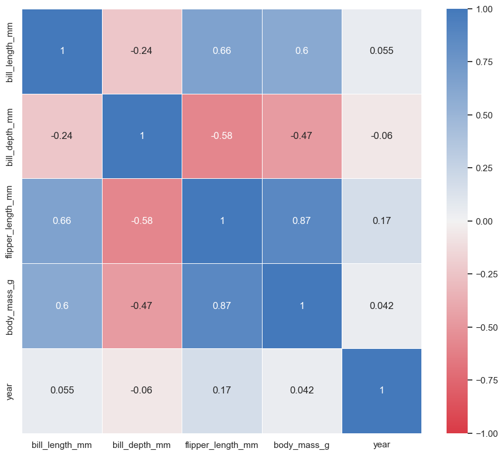

```python
sns.heatmap(
    data=preprocessed_penguins_df.corr(numeric_only=True),
    center=0,
    vmin=-1,
    vmax=1,
    linewidths=0.5,
    annot=True,
    cmap=sns.diverging_palette(10,250, n=8, as_cmap=True)
)
```

La intensidad con la se muestran los colores, es la proporción de intensidad de la correlación.

##### **Observaciones:**

- La variable **Year** no está correlacionada con ninguna de nuestras variables, ya que tiene un valor cercano a 0.
- Las variables del peso y longitud de ala, tienen una correlación fuerte = 0.87.

Así de esta forma se puede observar si las variables tienen una correlación positiva o negativa.

También podemos cambiar la gráfica por un `cluster map`

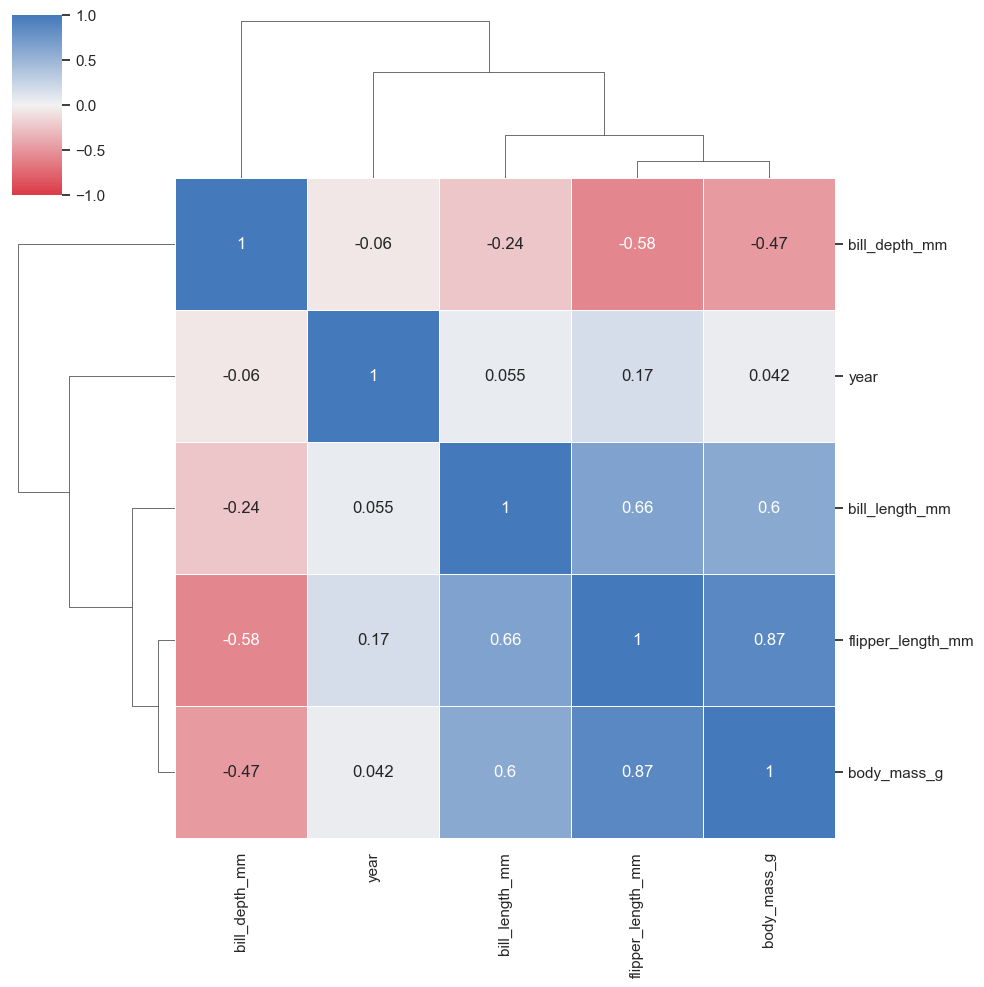

```python
sns.clustermap(
    data=preprocessed_penguins_df.corr(numeric_only=True),
    center=0,
    vmin=-1,
    vmax=1,
    linewidths=0.5,
    annot=True,
    cmap=sns.diverging_palette(10,250, n=8, as_cmap=True)
)
```

Lo que hace `cluster_map` es agrupar nuestros datos, según el valor que tenga la matriz. De esta forma es más fácil correlacionar variables de manera positiva, negativa y por intensidad.

Sin embargo podemos añadir variables que no estamos considerando.

También nos interesaría saber si alguna de estas variables está correlacionada con el sexo.